# automatization_notebook_03

2023-10-27

# Чтение данных

В вашем варианте нужно использовать датасет framingham.

```r
data_raw <- read_csv("data/raw/framingham.csv")
```

# Выведите общее описание данных

```r
data_raw %>% summary()
```

```
##       male             age          education     currentSmoker
##  Min.   :0.0000   Min.   :32.00   Min.   :1.000   Min.   :0.0000
##  1st Qu.:0.0000   1st Qu.:42.00   1st Qu.:1.000   1st Qu.:0.0000
##  Median :0.0000   Median :49.00   Median :2.000   Median :0.0000
##  Mean   :0.4292   Mean   :49.58   Mean   :1.979   Mean   :0.4941
##  3rd Qu.:1.0000   3rd Qu.:56.00   3rd Qu.:3.000   3rd Qu.:1.0000
##  Max.   :1.0000   Max.   :70.00   Max.   :4.000   Max.   :1.0000
##                                   NA's   :105
##    cigsPerDay         BPMeds        prevalentStroke     prevalentHyp
##  Min.   : 0.000   Min.   :0.00000   Min.   :0.000000   Min.   :0.0000
##  1st Qu.: 0.000   1st Qu.:0.00000   1st Qu.:0.000000   1st Qu.:0.0000
##  Median : 0.000   Median :0.00000   Median :0.000000   Median :0.0000
##  Mean   : 9.003   Mean   :0.02963   Mean   :0.005899   Mean   :0.3105
##  3rd Qu.:20.000   3rd Qu.:0.00000   3rd Qu.:0.000000   3rd Qu.:1.0000
##  Max.   :70.000   Max.   :1.00000   Max.   :1.000000   Max.   :1.0000
##  NA's   :29       NA's   :53
##     diabetes          totChol          sysBP           diaBP
##  Min.   :0.00000   Min.   :107.0   Min.   : 83.5   Min.   : 48.00
##  1st Qu.:0.00000   1st Qu.:206.0   1st Qu.:117.0   1st Qu.: 75.00
##  Median :0.00000   Median :234.0   Median :128.0   Median : 82.00
##  Mean   :0.02572   Mean   :236.7   Mean   :132.4   Mean   : 82.89
##  3rd Qu.:0.00000   3rd Qu.:263.0   3rd Qu.:144.0   3rd Qu.: 89.88
##  Max.   :1.00000   Max.   :696.0   Max.   :295.0   Max.   :142.50
##                    NA's   :50
##       BMI          heartRate         glucose         TenYearCHD
##  Min.   :15.54   Min.   : 44.00   Min.   : 40.00   Min.   :0.000
##  1st Qu.:23.07   1st Qu.: 68.00   1st Qu.: 71.00   1st Qu.:0.000
##  Median :25.40   Median : 75.00   Median : 78.00   Median :0.000
##  Mean   :25.80   Mean   : 75.88   Mean   : 81.97   Mean   :0.152
##  3rd Qu.:28.04   3rd Qu.: 83.00   3rd Qu.: 87.00   3rd Qu.:0.000
##  Max.   :56.80   Max.   :143.00   Max.   :394.00   Max.   :1.000
##  NA's   :19      NA's   :1        NA's   :388
```

# Очистка данных

1. Уберите переменные, в которых пропущенных значений больше 20% или уберите субъектов со слишком большим количеством пропущенных значений. Или совместите оба варианта. Напишите обоснование, почему вы выбрали тот или иной вариант:

```r
# Подсчет процента пропущенных значений для каждой переменной
missing_percentage <- data_raw %>%
  summarise_all(~ sum(is.na(.)) / n()) %>%
  gather() %>%
  filter(value > 0.20)

if (nrow(missing_percentage) == 0) {
  cat("Переменных с процентом пропущенных значений > 20% нет.\n")
} else {
  cat("Переменные с процентом пропущенных значений более 20%:\n")
  cat(missing_percentage$key, sep = "\n")
}
```

```
## Переменных с процентом пропущенных значений > 20% нет.
```

```r
# Код для того что бы отсортировать те перменные(столбцы) в которых процент
# пропущенных значений более 20%
#
# Я закомментировал этот код сознательно так как не считаю что мы в праве
# отбросить те переменные в значениях которой такое количество пропусков

##################################################################
# data_raw_clean <- data_raw %>%
#   filter(rowSums(is.na(.)) / ncol(data_raw) <= 0.2)
##################################################################


# Указание порога для процента пропущенных значений
limit_per_NA_in_row <- 0.20

# Отфильтровать строки, где более 20% значений пропущены
filtered_data <- data_raw %>%
  mutate(percent_NA_row = rowSums(is.na(.)) / ncol(data_raw)) %>%
  filter(percent_NA_row > limit_per_NA_in_row)

# Вывод отфильтрованных строк
if (nrow(filtered_data) > 0) {
  cat("Количество строк в коротых пропущено более 20% значений: ", nrow(filtered_data))
} else {
  cat("В датасете нет строк в которых пропущено более чем 20% записей.")

}
```

```
## В датасете нет строк в которых пропущено более чем 20% записей.
```

```r
# МНЕНИЕ:
# В общем случае я так же не считаю корректным отбрасывать значения в которых
# пропущены значения более корректным НА МОЙ ВЗГЛЯД будет импутировать
# такие данные, если это возможно.


# Создадим функцию для проверки названий и типов переменных с NA значениями
# Функция check_variables_with_na будет принимать только один агрумент -- это название датасета

check_variables_with_na <- function(data) {
  variables_with_na <- sapply(data, function(x) any(is.na(x)))
  variable_names <- names(variables_with_na)
  variable_types <- sapply(data, class)

  has_na_values <- any(variables_with_na)

  if (has_na_values) {
    cat("Список переменных с указанием типов в которых есть хотя бы одно NA значение:\n")
    for (i in 1:length(variable_names)) {
      if (variables_with_na[i]) {
        cat("Variable:", variable_names[i], "Type:", variable_types[i], "\n")
      }
    }
  } else {
    cat("Нет переменных с NA значениями.\n")
  }
}

check_variables_with_na(data_raw)
```

```
## Список переменных с указанием типов в которых есть хотя бы одно NA значение:
## Variable: education Type: numeric
## Variable: cigsPerDay Type: numeric
## Variable: BPMeds Type: numeric
## Variable: totChol Type: numeric
## Variable: BMI Type: numeric
## Variable: heartRate Type: numeric
## Variable: glucose Type: numeric
```

**Обоснование**:

Все переменные в которых есть пропуски - это числовые перменные кроме education и BPMeds. Как мне кажется это категориальная пременная в числовом формате.

Представим что у нас есть возможность связаться со спонсором и обсудить алгоритм импутации.

Были достигнуты следующие договоренности:

```r
columns_to_replace_na <- c("cigsPerDay"
                          , "totChol"
                          , "BMI"
                          , "heartRate"
                          , "glucose")


data_with_imputation <- data_raw %>%
  mutate(
    across(all_of(columns_to_replace_na), ~ ceiling(median(., na.rm = TRUE))),
    education = ifelse(is.na(education), 5, education),
    BPMeds    = ifelse(is.na(BPMeds),    2, BPMeds)
    )

check_variables_with_na(data_with_imputation)
```

```
## Нет переменных с NA значениями.
```

2. Переименуйте переменные в человекочитаемый вид (что делать с пробелами в названиях?);

Я решил заменить названия столбцов на соответствующие человекочитаемые названия, а так же заменить пробелы нижним подчеркиванием

```r
# Создаем словарь переводов
translation_dict <- c(
  "Пол" = "male",
  "Возраст" = "age",
  "Образование" = "education",
  "Текущий_курильщик" = "currentSmoker",
  "Сигарет_в_день" = "cigsPerDay",
  "Препараты_от_артериального_давления" = "BPMeds",
  "Распространенный_инсульт" = "prevalentStroke",
  "Распространенное_гипертония" = "prevalentHyp",
  "Сахарный_диабет" = "diabetes",
  "Общий_холестерин" = "totChol",
  "Систолическое_давление" = "sysBP",
  "Диастолическое_давление" = "diaBP",
  "Индекс_массы_тела" = "BMI",
  "Частота_сердечных_сокращений" = "heartRate",
  "Уровень_глюкозы" = "glucose",
  "Риск_CHD_на_10_лет" = "TenYearCHD"
)


# Переименовываем колонки в data frame
data_with_imputation_1 <- rename(data_with_imputation, !!!translation_dict)
```

3. В соответствии с описанием данных приведите переменные к нужному типу (numeric или factor);

```r
# Создадим списки для numeric или factor переменных
numeric_list <- c("Возраст"
                  , "Сигарет_в_день"
                  , "Общий_холестерин"
                  , "Систолическое_давление"
                  , "Диастолическое_давление"
                  , "Индекс_массы_тела"
                  , "Частота_сердечных_сокращений"
                  , "Уровень_глюкозы")

factor_list  <- c( "Пол"
                  , "Образование"
                  , "Текущий_курильщик"
                  , "Препараты_от_артериального_давления"
                  , "Распространенный_инсульт"
                  , "Распространенное_гипертония"
                  , "Сахарный_диабет"
                  , "Риск_CHD_на_10_лет")

data_with_imputation_2 <- data_with_imputation_1 %>%
  mutate(
    # Привести числовые переменные к типу numeric
    across(all_of(numeric_list), ~ as.numeric(.)),

    # Привести факторные переменные к типу factor
    across(all_of(factor_list), ~ as.factor(.))

  )
```

4. Отсортируйте данные по возрасту по убыванию;
5. Сохраните в файл outliers.csv субъектов, которые являются выбросами (например, по правилу трёх сигм) — это необязательное задание со звёздочкой;
6. Присвойте получившийся датасет переменной “cleaned_data”.

```r
# пропустил задание 5, подскажите, пожалуйста в какую сторону думать? 🤔

cleaned_data <- data_with_imputation_2 %>%
  arrange(desc(Возраст))
```

# Сколько осталось переменных?

```r
count_of_vars <- ncol(cleaned_data)
cat("Количество переменных в датасете:", count_of_vars)
```

```
## Количество переменных в датасете: 16
```

# Сколько осталось случаев?

```r
count_of_rows <- nrow(cleaned_data)
cat("Количество наблюдений в датасете:", count_of_rows)
```

```
## Количество наблюдений в датасете: 4238
```

# Есть ли в данных идентичные строки?

```r
# Проверка датасета на наличие полных дубликатов
has_duplicates <- any(duplicated(cleaned_data))

if (has_duplicates) {
  cat("Датасет содержит полные дубликаты строк.\n")
} else {
  cat("Датасет не содержит полных дубликатов строк.\n")
}
```

```
## Датасет содержит полные дубликаты строк.
```

```r
# Удалим полные дубликаты:

cleaned_data <- cleaned_data %>%
  distinct()

cat("Полные дубликаты удалены\n")
```

```
## Полные дубликаты удалены
```

# Сколько всего переменных с пропущенными значениями в данных и сколько пропущенных точек в каждой такой переменной?

```r
#Все пропущенные данные были заменены, смотрите, пожалуйста задание 1
```

# Описательные статистики

## Количественные переменные

1. Рассчитайте для всех количественных переменных для каждой группы (TenYearCHD):

1.1) Количество значений;

1.2) Количество пропущенных значений;

1.3) Среднее;

1.4) Медиану;

1.5) Стандартное отклонение;

1.6) 25% квантиль и 75% квантиль;

1.7) Интерквартильный размах;

1.8) Минимум;

1.9) Максимум;

1.10) 95% ДИ для среднего - задание со звёздочкой.

```r
result <- data_with_imputation_2 %>%
  select(all_of(c(numeric_list, "Риск_CHD_на_10_лет"))) %>%
  group_by(Риск_CHD_на_10_лет) %>%
  summarise(across(where(is.numeric), list(
    n = ~n(),
    missing = ~sum(is.na(.)),
    mean = mean,
    mean_ci_lower = ~mean(.) - 1.96 * (sd(.) / sqrt(length(.))),  # 95% нижний предел
    mean_ci_upper = ~mean(.) + 1.96 * (sd(.) / sqrt(length(.))),  # 95% верхний предел
    median = median,
    sd = sd,
    quantile_25 = ~quantile(., 0.25),
    quantile_75 = ~quantile(., 0.75),
    iqr = ~quantile(., 0.75) - quantile(., 0.25),
    min = min,
    max = max
  )))

result_table <- result %>%
  pivot_longer(cols = -Риск_CHD_на_10_лет, names_to = "Statistic", values_to = "Value") %>%
  pivot_wider(names_from = Риск_CHD_на_10_лет, values_from = Value)

print(result_table)
```

```
## # A tibble: 96 × 3
##    Statistic                 `0`    `1`
##    <chr>                   <dbl>  <dbl>
##  1 Возраст_n             3594    644
##  2 Возраст_missing          0      0
##  3 Возраст_mean            48.8   54.1
##  4 Возраст_mean_ci_lower   48.5   53.5
##  5 Возраст_mean_ci_upper   49.0   54.8
##  6 Возраст_median          48     55
##  7 Возраст_sd               8.41   8.01
##  8 Возраст_quantile_25     42     48
##  9 Возраст_quantile_75     55     61
## 10 Возраст_iqr             13     13
## # ℹ 86 more rows
```

## Категориальные переменные

1. Рассчитайте для всех категориальных переменных для каждой группы (TenYearCHD):

1.1) Абсолютное количество;

1.2) Относительное количество внутри группы;

1.3) 95% ДИ для доли внутри группы - задание со звёздочкой.

```r
calculate_percentage <- function(data, group_var, factor_var) {
  result <- data %>%
    select({{ factor_var }}) %>%
    count(Риск_CHD_на_10_лет, {{ group_var }}) %>%
    group_by(Риск_CHD_на_10_лет) %>%
    mutate(`процент по группе` = (n / sum(n)) * 100) %>%
    ungroup() %>%
    mutate(`процент по популяции` = (n / sum(n)) * 100)

  return(result)
}

# Пример использования функции с заменой "Пол"
result_factor_пол <- calculate_percentage(data_with_imputation_2, Пол, factor_list)
result_factor_Образование <- calculate_percentage(data_with_imputation_2, Образование, factor_list)
result_factor_Текущий_курильщик <- calculate_percentage(data_with_imputation_2, Текущий_курильщик, factor_list)
result_factor_Препараты_от_артериального_давления <- calculate_percentage(data_with_imputation_2, Препараты_от_артериального_давления, factor_list)
result_factor_Распространенный_инсульт <- calculate_percentage(data_with_imputation_2, Распространенный_инсульт, factor_list)
result_factor_Распространенное_гипертония <- calculate_percentage(data_with_imputation_2, Распространенное_гипертония, factor_list)
result_factor_Сахарный_диабет <- calculate_percentage(data_with_imputation_2, Сахарный_диабет, factor_list)
```

# Визуализация

## Количественные переменные

1. Для каждой количественной переменной сделайте боксплоты по группам. Расположите их либо на отдельных рисунках, либо на одном, но читаемо;
2. Наложите на боксплоты beeplots - задание со звёздочкой.
3. Раскрасьте боксплоты с помощью библиотеки RColorBrewer.

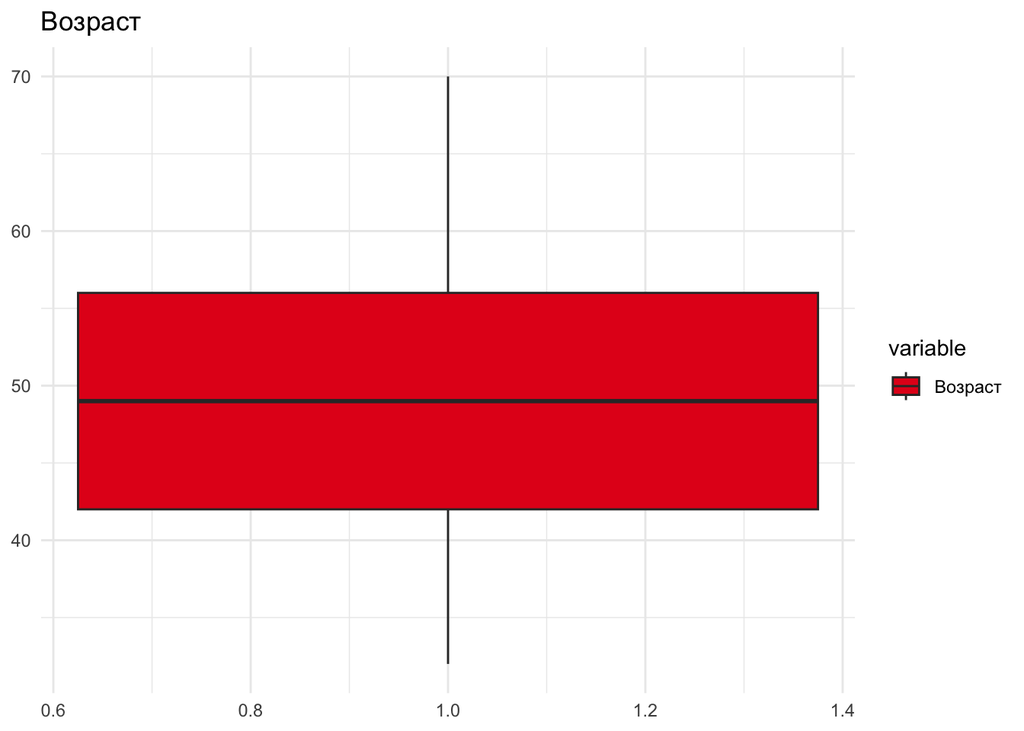

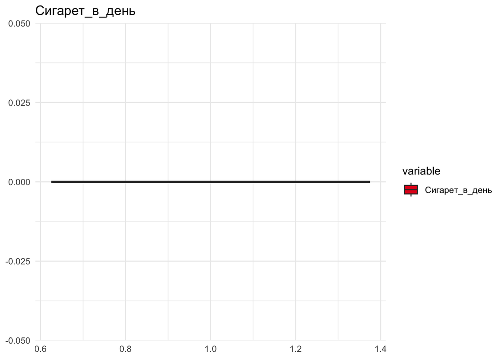

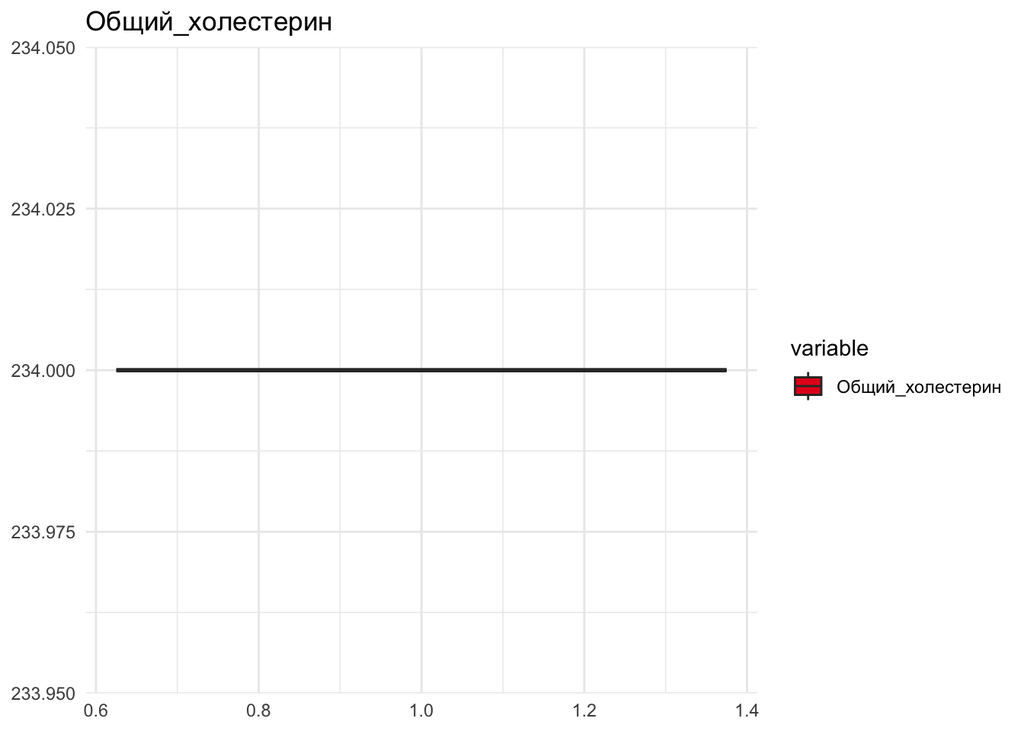

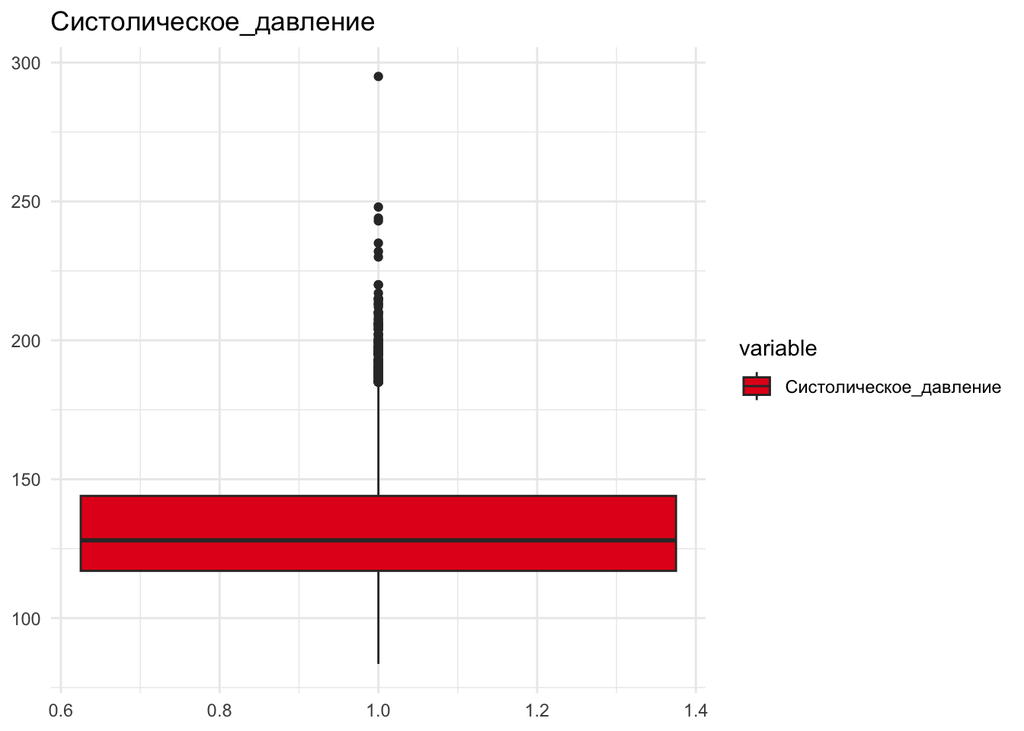

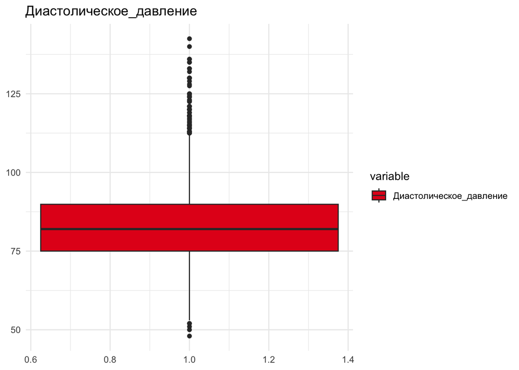

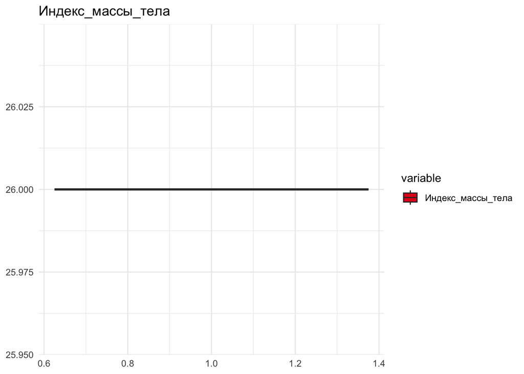

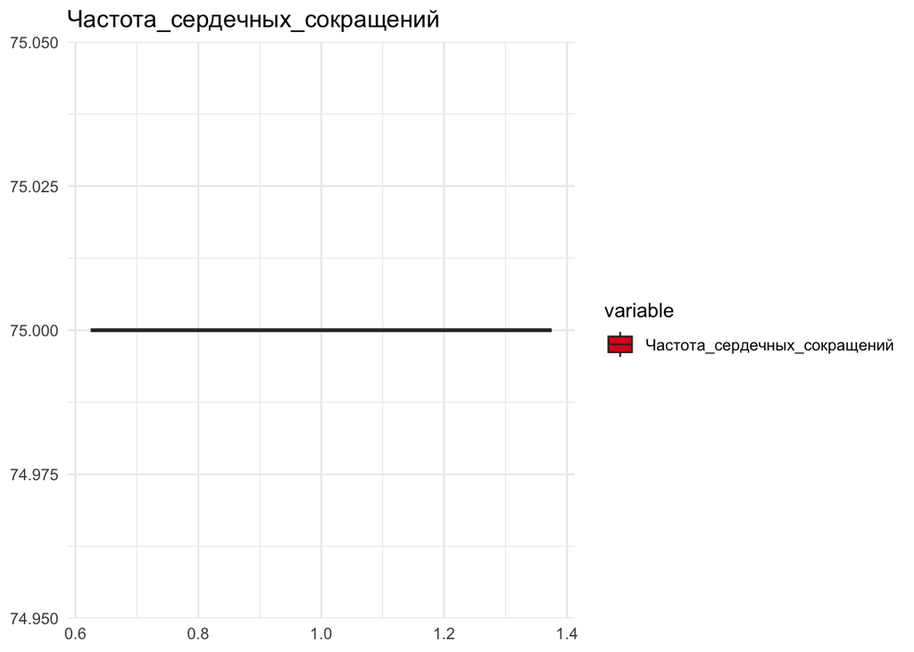

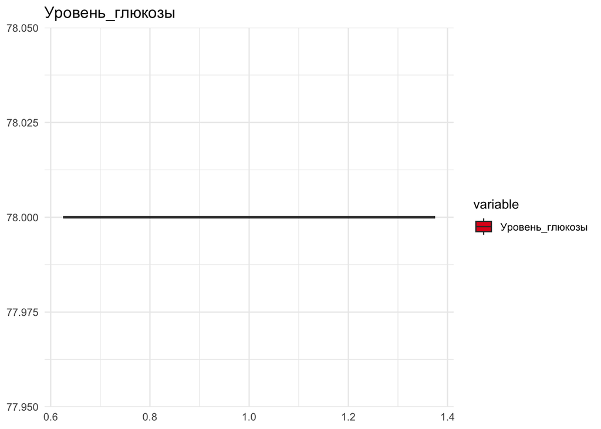

```r
library(ggplot2)
library(RColorBrewer)

# Выбор палитры цветов
color_palette <- brewer.pal(8, "Set1")  # Выберите нужную палитру цветов

# Создание боксплотов с раскраской
for (variable in numeric_list) {
  # Создайте боксплот с ggplot2
  plot_data <- data_with_imputation_2
  p <- ggplot(data = plot_data, aes(x = 1, y = .data[[variable]], fill = variable)) +
    geom_boxplot() +
    labs(title = variable) +
    theme_minimal() +
    theme(axis.title.x = element_blank(),
          axis.title.y = element_blank()) +
    scale_fill_manual(values = color_palette)  # Установите цвета из палитры

  # Вывод боксплота
  print(p)
}
```

## Категориальные переменные

1. Сделайте подходящие визуализации категориальных переменных. Обоснуйте, почему выбрали именно этот тип.

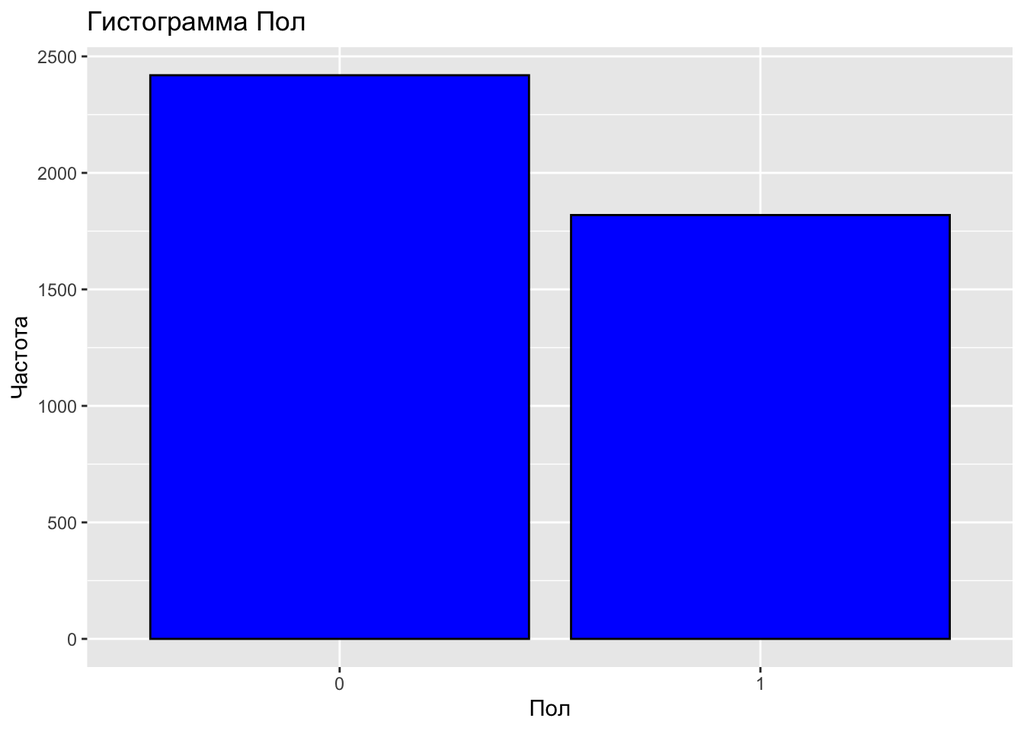

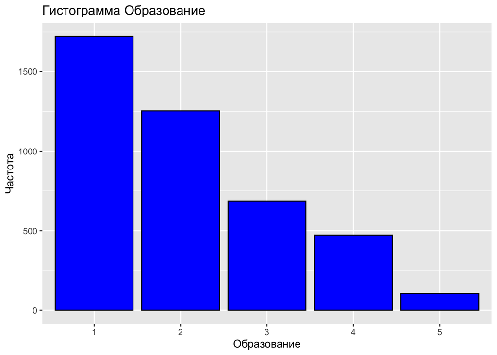

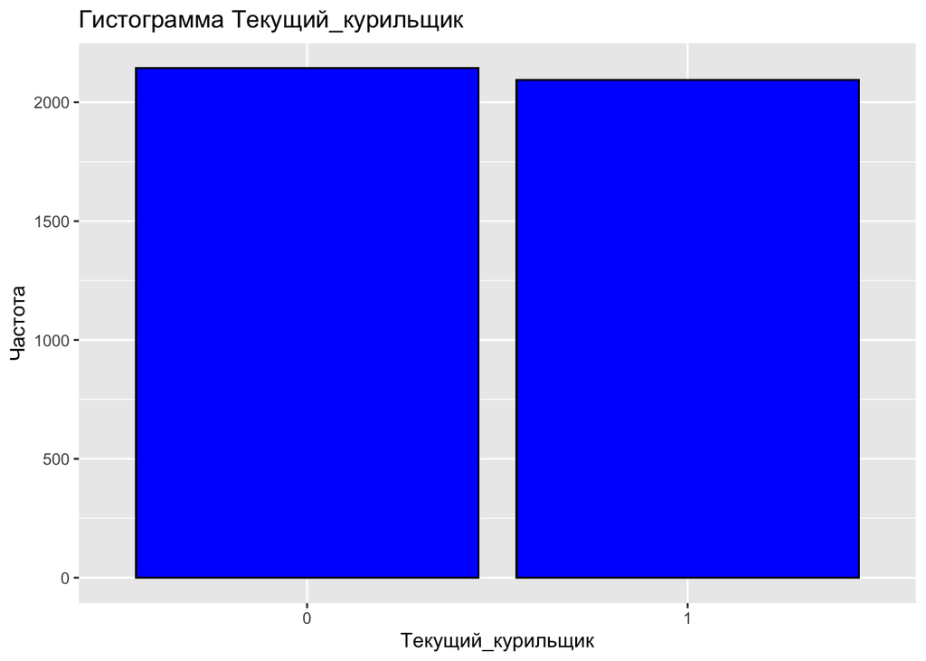

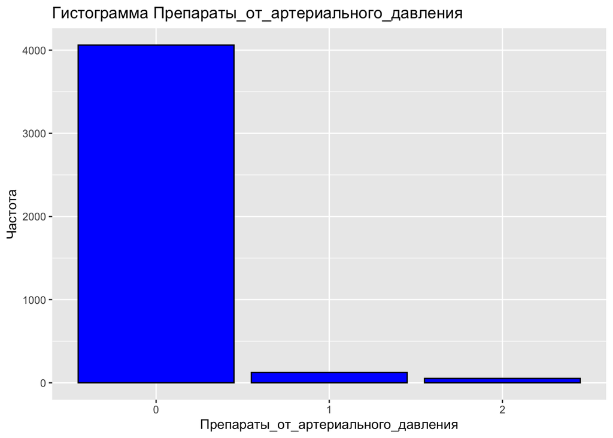

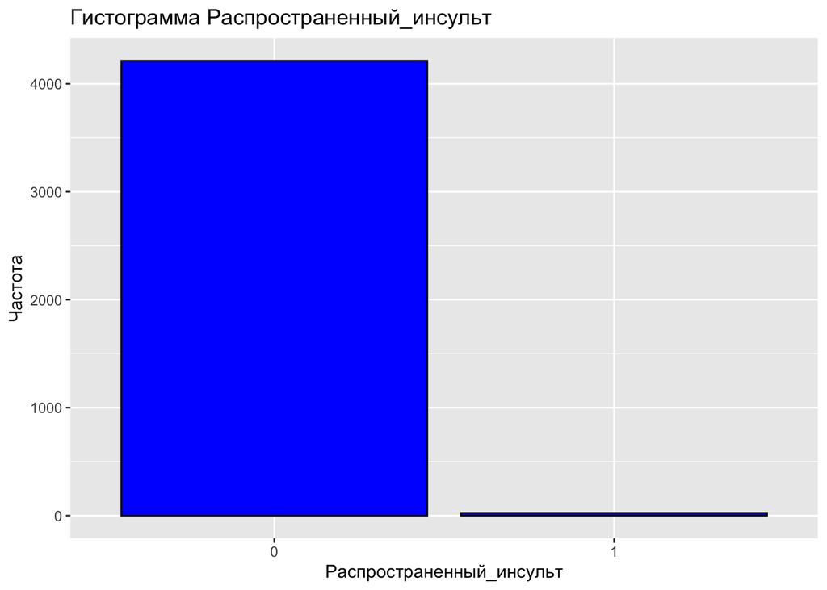

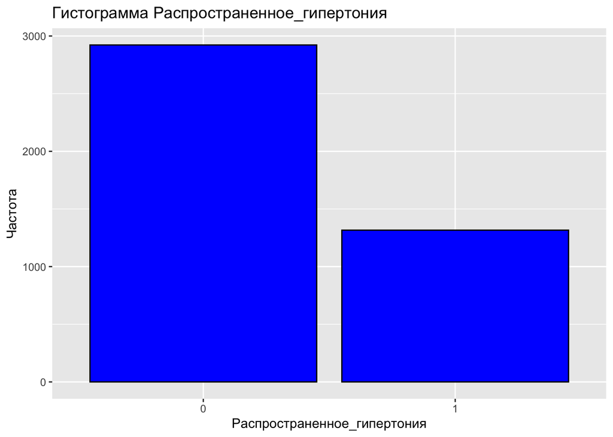

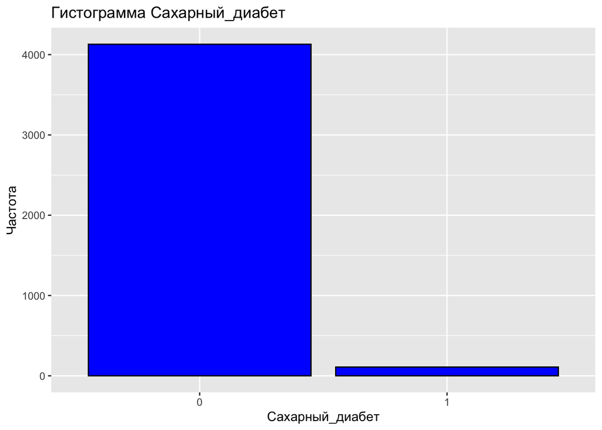

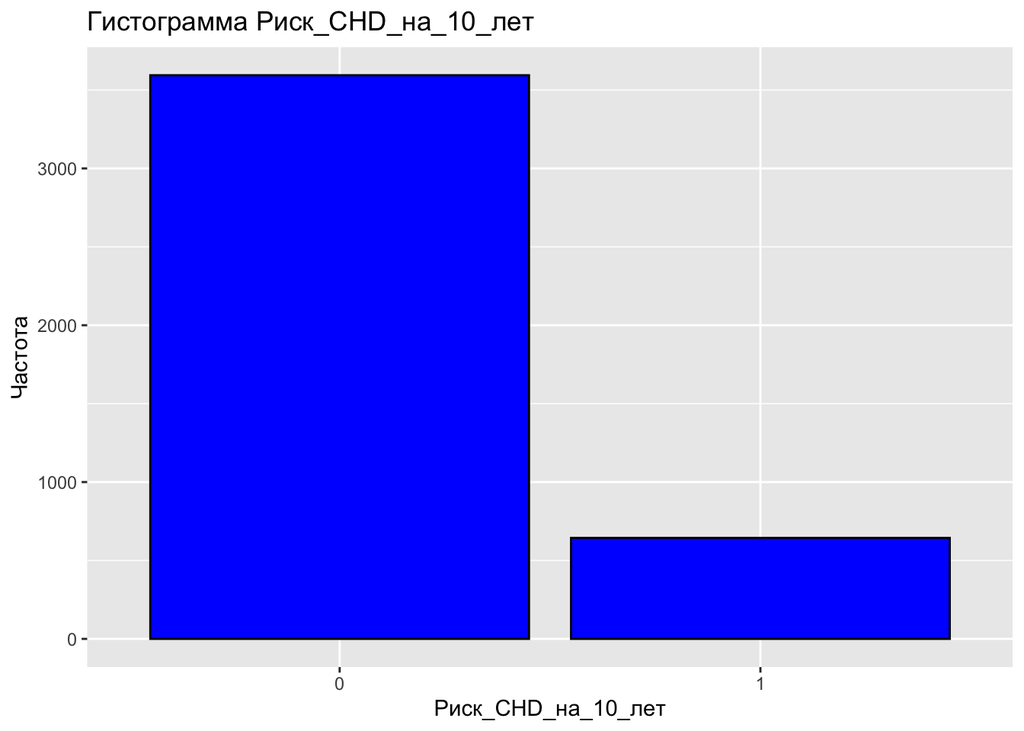

```r
# create dummy data
data <- data_with_imputation_2 %>% select(Пол)

# Цикл для создания графиков
for (variable in factor_list) {
  if (is.factor(data_with_imputation_2[[variable]])) {
    # Если переменная является фактором, создать столбчатую диаграмму
    plot <- ggplot(data_with_imputation_2, aes_string(x = variable)) +
      geom_bar(fill = "blue", color = "black") +
      labs(title = paste("Гистограмма", variable), x = variable, y = "Частота")
  } else {
    # Если переменная не является фактором, создать гистограмму
    plot <- ggplot(data_with_imputation_2, aes_string(x = variable)) +
      geom_histogram(fill = "blue", color = "black") +
      labs(title = paste("Гистограмма", variable), x = variable, y = "Частота")
  }

  print(plot)  # Вывод графика
}
```

### Обоснование

Я выбрал гистораммы для наглядного отображения размеров групп категориальных перменных

# Статистические оценки

## Проверка на нормальность

1. Оцените каждую переменную на соответствие нормальному распределению с помощью теста Шапиро-Уилка. Какие из переменных являются нормальными и как как вы это поняли?

```r
# Создайте пустой список для сохранения результатов теста
results <- vector("list", length(numeric_list))
 cat("Cоответствие нормальному распределению - тест Шапиро-Уилка: \n")
```

```
## Cоответствие нормальному распределению - тест Шапиро-Уилка:
```

```r
# Пройдите по каждой переменной и выполните тест Шапиро-Уилка, если данные разнообразны
for (i in 1:length(numeric_list)) {
  var <- numeric_list[i]
  if (length(unique(data_with_imputation_2[[var]])) > 1) {
    result <- shapiro.test(data_with_imputation_2[[var]])
    results[[i]] <- result$p.value
  } else {
    cat(paste("Переменная ", var, "имеет одинаковые значения и не может быть протестирована\n"))
  }
}
```

```
## Переменная  Сигарет_в_день имеет одинаковые значения и не может быть протестирована
## Переменная  Общий_холестерин имеет одинаковые значения и не может быть протестирована
## Переменная  Индекс_массы_тела имеет одинаковые значения и не может быть протестирована
## Переменная  Частота_сердечных_сокращений имеет одинаковые значения и не может быть протестирована
## Переменная  Уровень_глюкозы имеет одинаковые значения и не может быть протестирована
```

```r
# Выведите результаты теста для переменных с разнообразными данными
for (i in 1:length(numeric_list)) {
  var <- numeric_list[i]
  if (!is.null(results[[i]])) {
    cat(paste("Переменная ", var, ": p-значение =", results[[i]], "\n"))
  }
}
```

```
## Переменная  Возраст : p-значение = 3.96326041127679e-30
## Переменная  Систолическое_давление : p-значение = 1.57484814370838e-39
## Переменная  Диастолическое_давление : p-значение = 2.8560394374895e-27
```

```r
# Преобразуйте results в вектор
results <- unlist(results)

# Оцените, какие переменные считаются нормально распределенными
alpha <- 0.05
normal_variables <- numeric_list[results > alpha]

if (length(normal_variables) > 0) {
  cat("Нормально распределенные переменные:", normal_variables, "\n")
} else {
  cat("Нет нормально распределенных переменных при уровне значимости alpha =", alpha, "\n")
}
```

```
## Нет нормально распределенных переменных при уровне значимости alpha = 0.05
```

2. Постройте для каждой количественной переменной QQ-плот. Отличаются ли выводы от теста Шапиро-Уилка? Какой метод вы бы предпочли и почему?

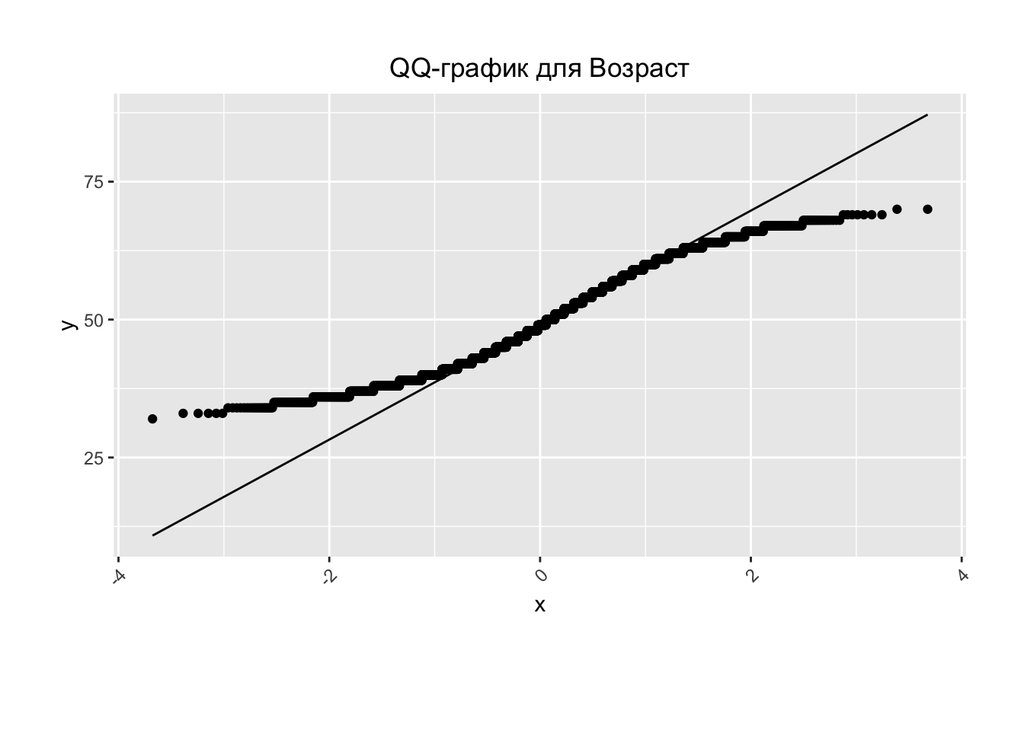

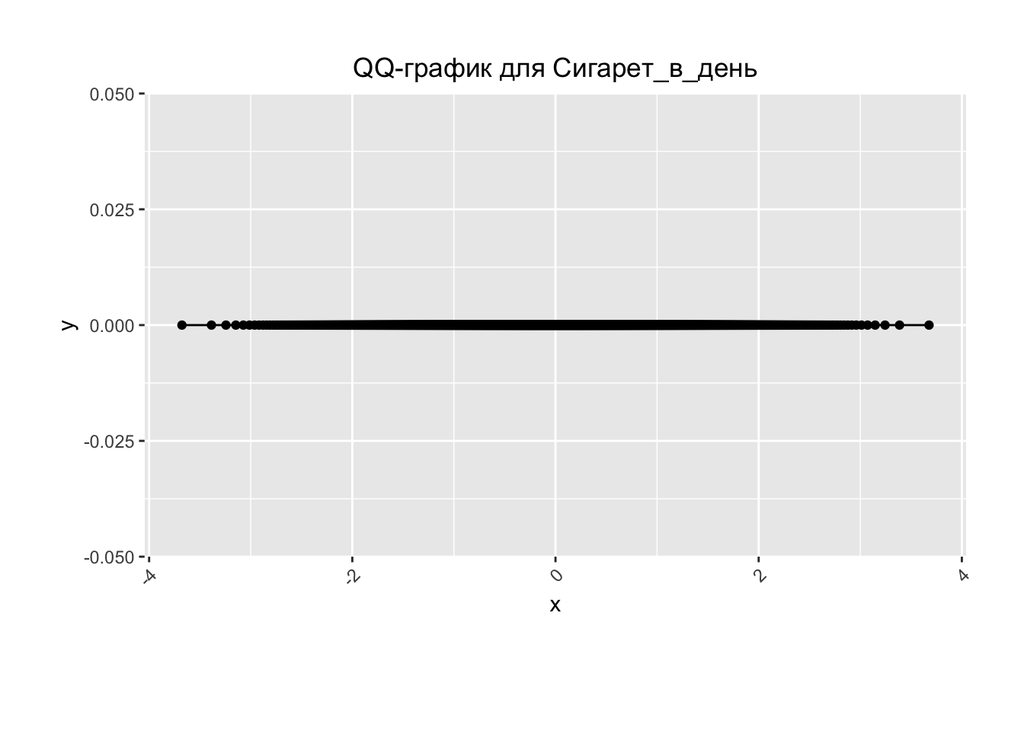

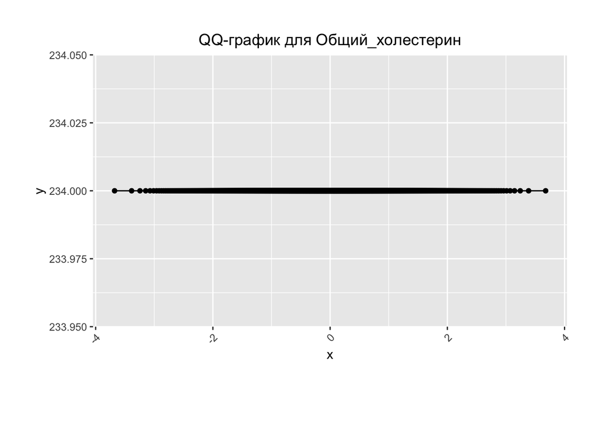

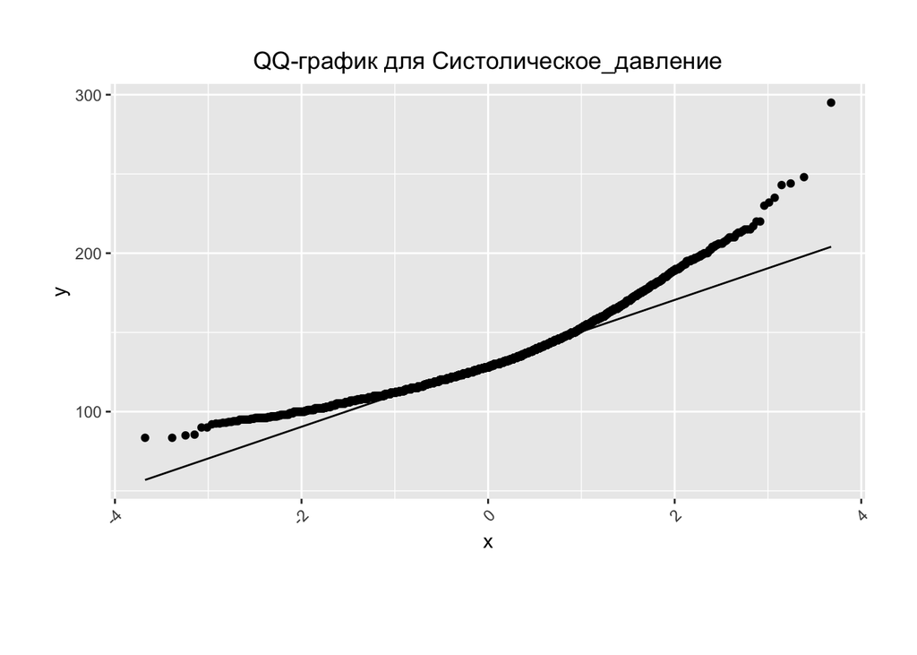

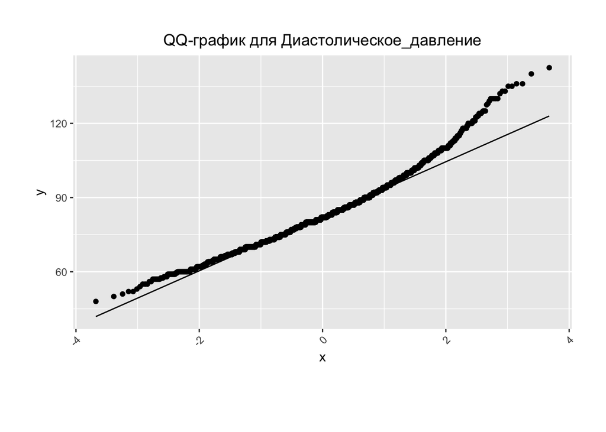

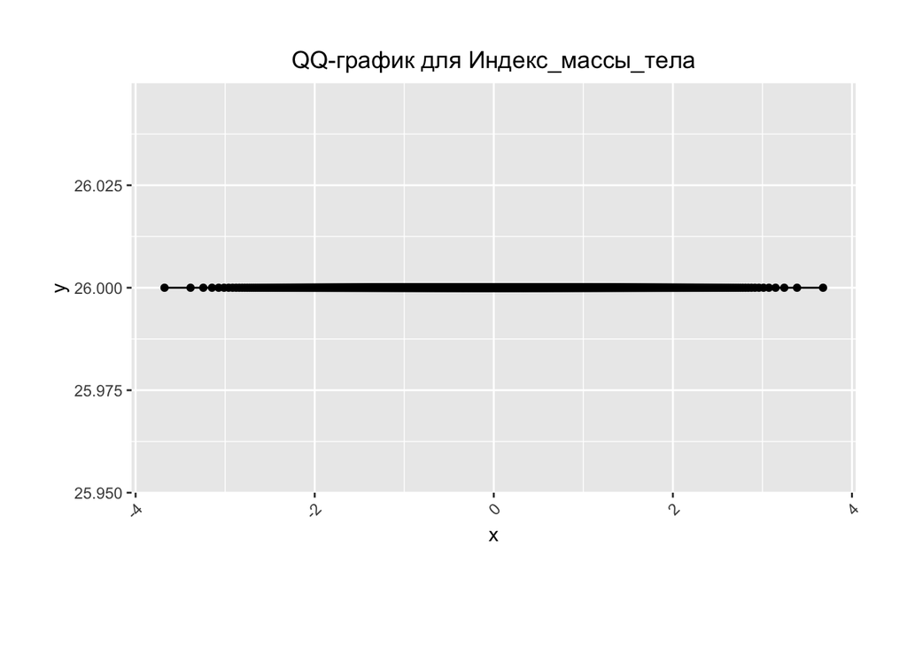

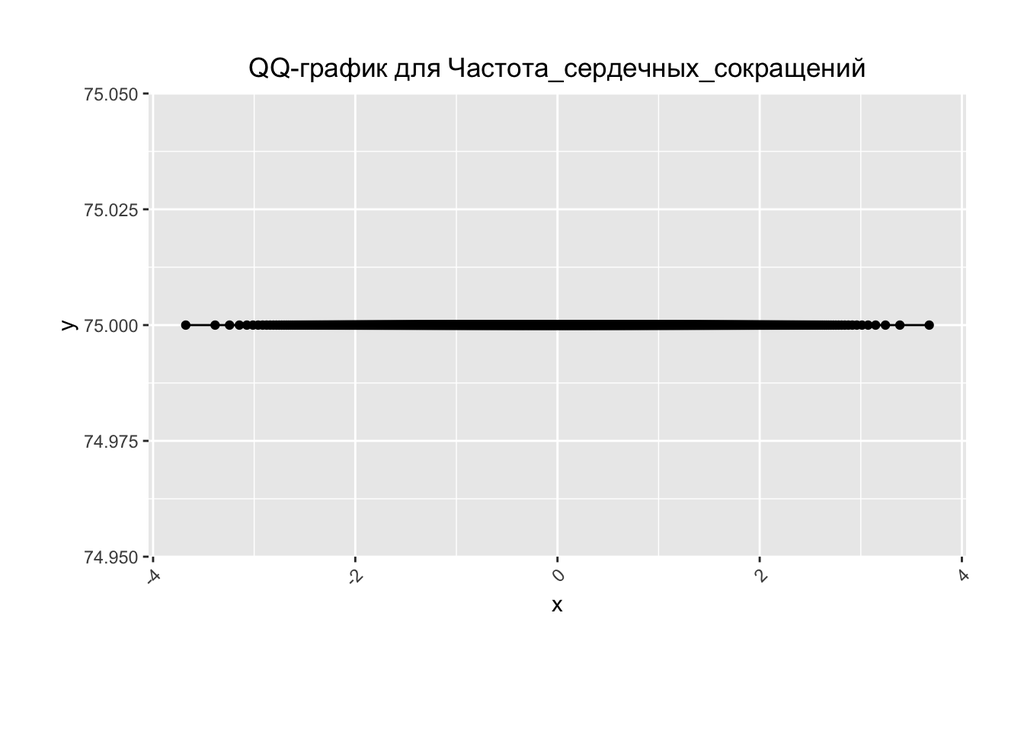

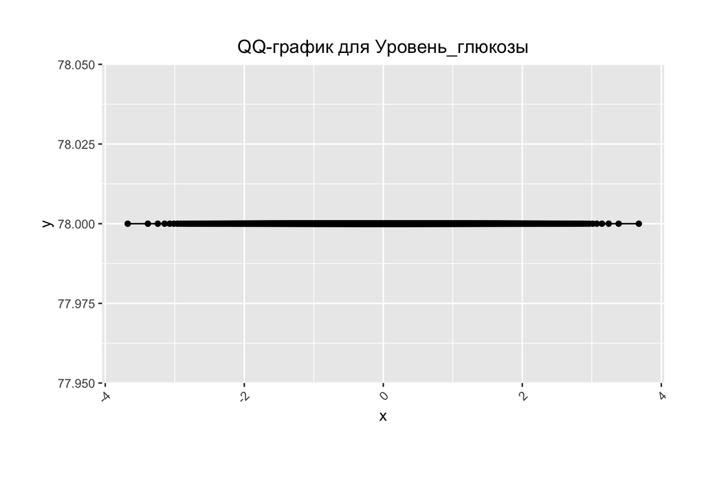

```r
# Установка и подключение необходимых библиотек
# install.packages("ggplot2")
# install.packages("dplyr")
library(ggplot2)
library(dplyr)

# Выбор только количественных переменных из вашего датасета
numeric_vars <- data_with_imputation_2 %>% select_if(is.numeric)

# Функция для создания и отображения QQ-графика
create_qq_plot <- function(data, var_name) {
  p <- ggplot(data, aes(sample = !!sym(var_name))) +
    geom_qq() +
    geom_qq_line() +
    labs(title = paste("QQ-график для", var_name)) +
    theme(axis.text.x = element_text(angle = 45, hjust = 1)) +  # Установка ориентации названия
    theme(plot.title = element_text(hjust = 0.5)) +  # Выравнивание названия по центру
    theme(plot.margin = margin(1, 1, 2, 1, "cm"))  # Увеличение размера графика
  print(p)
}

# Создайте и отобразите QQ-графики для каждой переменной
for (var in colnames(numeric_vars)) {
  create_qq_plot(data_with_imputation_2, var)
}
```

Данные следуют нормальному распределению: Если точки на QQ-графике следуют прямой линии (линия диагонали), это означает, что данные очень близки к нормальному распределению. Такие точки располагаются вдоль диагонали, и отклонения от диагонали незначительны.

Диосталическое и Систолическое давление, а так же возраст в части распределения “походят” на “нормальное”, однако данные смещены влево или вправо, это может свидетельствовать о наличии асимметрии в данных, например, о наличии длинного хвоста влево. Если точки отклоняются вправо, это может свидетельствовать о наличии асимметрии с хвостом вправо.

Тяжелые хвосты (Fat Tails): Если точки на QQ-графике выходят за пределы диагонали в область хвостов, это может указывать на наличие тяжелых хвостов в данных, что означает, что в данных есть выбросы или экстремальные значения.

С-образная кривая: Если точки на QQ-графике образуют S-образную кривую, это может указывать на бимодальное распределение, то есть на наличие двух пиков в данных.

Прямая линия с изгибами: Если точки на QQ-графике образуют прямую линию с изгибами, это может свидетельствовать о нелинейной зависимости данных, где некоторая трансформация данных может сделать их ближе к нормальному распределению.

Интерпретация QQ-графиков зависит от контекста и целей анализа данных. Они предоставляют важную информацию о распределении данных и могут помочь в выявлении асимметрии, выбросов и нелинейных зависимостей в данных.

3. Ниже напишите, какие ещё методы проверки на нормальность вы знаете и какие у них есть ограничения.

**Напишите текст здесь** До этого момента я знал только QQ тест для проверки распределения на “нормальность” дополнительную информацию пришлось гуглить :)

Тест Шапиро-Уилка: Преимущество: Хорошо работает с небольшими выборками и имеет высокую чувствительность к даже небольшим отклонениям от нормальности. Ограничения: Может стать менее мощным при больших выборках. Особенно чувствителен к асимметрии данных. Тест Д’Агостино-Пирсона:

Преимущество: Более мощен для больших выборок, чем тест Шапиро-Уилка. Ограничения: Также может быть чувствителен к асимметрии данных. Тест Андерсона-Дарлинга:

Преимущество: Чувствителен к отклонениям от нормальности в хвостах распределения. Ограничения: Ограничен в применении для больших выборок. Q-Q графики:

Преимущество: Предоставляют визуальное представление распределения данных и могут помочь обнаружить отклонения от нормальности. Ограничения: Требуют субъективной интерпретации и могут быть менее точными для малых выборок. Графики ящика с усами (Boxplots):

Преимущество: Могут помочь обнаружить выбросы и асимметрию в данных. Ограничения: Не предоставляют статистической информации о нормальности. Количественные меры асимметрии и эксцесса:

Преимущество: Могут предоставить количественную оценку асимметрии и остроты пика распределения. Ограничения: Не проверяют нормальность напрямую и могут быть менее информативными в случае отклонений от нормальности.

## Сравнение групп

1. Сравните группы (переменная **TenYearCHD**) по каждой переменной (как количественной, так и категориальной). Для каждой переменной выберите нужный критерий и кратко обоснуйте его выбор в комментариях.

Я предполагаю что в данных есть всего три типа данных:

1. Для непрерывных переменных я буду использовать непараметрически тест Манна-Уитни так как на предыдущих шагах мы выяснили что распределение для нумерик перменных не соответствует нормальному распределению
2. Для категориальных переменных переменных будем использовать точный тест Фишера
3. Для бинарных переменных хи квадрат

```r
compare_data_0 <- data_with_imputation_2
compare_data_0 %>% summary()
```

```
##  Пол         Возраст      Образование Текущий_курильщик Сигарет_в_день
##  0:2419   Min.   :32.00   1:1720      0:2144            Min.   :0
##  1:1819   1st Qu.:42.00   2:1253      1:2094            1st Qu.:0
##           Median :49.00   3: 687                        Median :0
##           Mean   :49.58   4: 473                        Mean   :0
##           3rd Qu.:56.00   5: 105                        3rd Qu.:0
##           Max.   :70.00                                 Max.   :0
##  Препараты_от_артериального_давления Распространенный_инсульт
##  0:4061                              0:4213
##  1: 124                              1:  25
##  2:  53
##
##
##
##  Распространенное_гипертония Сахарный_диабет Общий_холестерин
##  0:2922                      0:4129          Min.   :234
##  1:1316                      1: 109          1st Qu.:234
##                                              Median :234
##                                              Mean   :234
##                                              3rd Qu.:234
##                                              Max.   :234
##  Систолическое_давление Диастолическое_давление Индекс_массы_тела
##  Min.   : 83.5          Min.   : 48.00          Min.   :26
##  1st Qu.:117.0          1st Qu.: 75.00          1st Qu.:26
##  Median :128.0          Median : 82.00          Median :26
##  Mean   :132.4          Mean   : 82.89          Mean   :26
##  3rd Qu.:144.0          3rd Qu.: 89.88          3rd Qu.:26
##  Max.   :295.0          Max.   :142.50          Max.   :26
##  Частота_сердечных_сокращений Уровень_глюкозы Риск_CHD_на_10_лет
##  Min.   :75                   Min.   :78      0:3594
##  1st Qu.:75                   1st Qu.:78      1: 644
##  Median :75                   Median :78
##  Mean   :75                   Mean   :78
##  3rd Qu.:75                   3rd Qu.:78
##  Max.   :75                   Max.   :78
```

```r
# compare_data_0 %>% filter(Сигарет_в_день != 0)
```

```r
# Создайте список для непрерывных переменных
continuous_variables <- c("Возраст"
                          , "Сигарет_в_день"
                          , "Общий_холестерин"
                          , "Систолическое_давление"
                          , "Диастолическое_давление"
                          , "Индекс_массы_тела"
                          , "Частота_сердечных_сокращений"
                          , "Уровень_глюкозы"
                          )
```

### Непрерывные перменные

```r
# Создайте список для интерпретации результатов
interpretation <- list()

# Выберите только необходимые переменные и данные
data_to_compare <- compare_data_0[, c("Риск_CHD_на_10_лет", continuous_variables)]

# Разбейте данные на две группы на основе "Риск_CHD_на_10_лет"
group_0 <- data_to_compare[data_to_compare$Риск_CHD_на_10_лет == "0", ]
group_1 <- data_to_compare[data_to_compare$Риск_CHD_на_10_лет == "1", ]

# Создайте пустой список для хранения результатов
results_and_interpretation <- list()

# Выполните тест Манна-Уитни для каждой непрерывной переменной и интерпретируйте результат
for (variable in continuous_variables) {
  if (length(unique(group_0[[variable]])) == 1 && length(unique(group_1[[variable]])) == 1) {
    interpretation_text <- "Все значения одинаковы и нет вариации в данных."
  } else {
    result <- wilcox.test(group_0[[variable]], group_1[[variable]], na.action = na.omit)
    p_value <- result$p.value
    if (!is.na(p_value)) {
      interpretation_text <- if (p_value < 0.05) {
        "Существует статистически значимая разница между группами."
      } else {
        "Статистически значимой разницы между группами не выявлено."
      }
    } else {
      interpretation_text <- "Данные содержат отсутствующие значения."
    }
  }

  result_and_interpretation <- paste(
    "Переменная:", variable,
    "p-значение:", ifelse(is.na(p_value), "NaN", p_value),
    "Интерпретация:", interpretation_text
  )

  results_and_interpretation[[variable]] <- result_and_interpretation
}

# Выведите результаты и интерпретацию
results_and_interpretation
```

```
## $Возраст
## [1] "Переменная: Возраст p-значение: 1.16585521298612e-47 Интерпретация: Существует статистически значимая разница между группами."
##
## $Сигарет_в_день
## [1] "Переменная: Сигарет_в_день p-значение: 1.16585521298612e-47 Интерпретация: Все значения одинаковы и нет вариации в данных."
##
## $Общий_холестерин
## [1] "Переменная: Общий_холестерин p-значение: 1.16585521298612e-47 Интерпретация: Все значения одинаковы и нет вариации в данных."
##
## $Систолическое_давление
## [1] "Переменная: Систолическое_давление p-значение: 9.82499736970136e-37 Интерпретация: Существует статистически значимая разница между группами."
##
## $Диастолическое_давление
## [1] "Переменная: Диастолическое_давление p-значение: 1.00597793905622e-17 Интерпретация: Существует статистически значимая разница между группами."
##
## $Индекс_массы_тела
## [1] "Переменная: Индекс_массы_тела p-значение: 1.00597793905622e-17 Интерпретация: Все значения одинаковы и нет вариации в данных."
##
## $Частота_сердечных_сокращений
## [1] "Переменная: Частота_сердечных_сокращений p-значение: 1.00597793905622e-17 Интерпретация: Все значения одинаковы и нет вариации в данных."
##
## $Уровень_глюкозы
## [1] "Переменная: Уровень_глюкозы p-значение: 1.00597793905622e-17 Интерпретация: Все значения одинаковы и нет вариации в данных."
```

### Ошибка: Сравнение категориальных перменных у меня не получилось не могли бы вы, пожалуйста, подсказать в чем я ошибаюсь?

```r
# # Создайте список для интерпретации результатов
# interpretation <- list()
#
# # Выберите только необходимые переменные и данные
# data_to_compare <- compare_data_0[, c("Риск_CHD_на_10_лет", "Образование", "Препараты_от_артериального_давления")]
#
# # Разбейте данные на две группы на основе "Риск_CHD_на_10_лет"
# group_0 <- data_to_compare[data_to_compare$Риск_CHD_на_10_лет == 0, ]
# group_1 <- data_to_compare[data_to_compare$Риск_CHD_на_10_лет == 1, ]
#
# # Создайте пустой список для хранения результатов
# results_and_interpretation <- list()
#
# # Объедините уровни переменных в обеих группах
# unique_levels <- unique(c(group_0$Образование, group_1$Образование, group_0$Препараты_от_артериального_давления, group_1$Препараты_от_артериального_давления))
#
# # Выполните тест хи-квадрат для каждой категориальной переменной и интерпретируйте результат
# for (variable in c("Образование", "Препараты_от_артериального_давления")) {
#   # Создайте таблицу сопряженности с учетом уровней в обеих группах
#   contingency_table <- table(factor(group_0[[variable]], levels = unique_levels), factor(group_1[[variable]], levels = unique_levels))
#
#   result <- chisq.test(contingency_table)
#   p_value <- result$p.value
#   interpretation_text <- if (p_value < 0.05) {
#     "Существует статистически значимая разница между группами."
#   } else {
#     "Статистически значимой разницы между группами не выявлено."
#   }
#
#   result_and_interpretation <- paste(
#     "Переменная:", variable,
#     "p-значение:", ifelse(is.na(p_value), "NaN", p_value),
#     "Интерпретация:", interpretation_text
#   )
#
#   results_and_interpretation[[variable]] <- result_and_interpretation
# }
#
# # Выведите результаты и интерпретацию
# results_and_interpretation
```

```r
# Создайте список для бинарных переменных
binary_variables <- c("Пол"
                      , "Текущий_курильщик"
                      , "Распространенный_инсульт"
                      , "Распространенное_гипертония"
                      , "Сахарный_диабет"
                      )

# Выберите только необходимые переменные и данные
data_to_compare <- compare_data_0[, c("Риск_CHD_на_10_лет", binary_variables)]

# Разбейте данные на две группы на основе "Риск_CHD_на_10_лет"
group_0 <- data_to_compare[data_to_compare$Риск_CHD_на_10_лет == "0", ]
group_1 <- data_to_compare[data_to_compare$Риск_CHD_на_10_лет == "1", ]

# Создадим функцию для подсчета таблицы сопряженности
create_contingency_table <- function(group_0, group_1) {
  unique_values <- unique(c(group_0, group_1))
  n_values <- length(unique_values)
  contingency_table <- matrix(0, nrow = n_values, ncol = 2)

  for (i in 1:n_values) {
    value <- unique_values[i]
    if (!is.na(value) && length(group_0) > 0 && length(group_1) > 0) {
      contingency_table[i, 1] <- sum(group_0 == value)
      contingency_table[i, 2] <- sum(group_1 == value)
    }
  }

  # Удалите строки, где оба столбца равны нулю
  contingency_table <- contingency_table[!(contingency_table[, 1] == 0 & contingency_table[, 2] == 0), ]

  rownames(contingency_table) <- unique_values[!is.na(unique_values)]
  colnames(contingency_table) <- c("Group_0", "Group_1")

  return(contingency_table)
}

# тест chi-squared только для бинарных переменных и интерпретируйте результат
results_and_interpretation <- list()

for (variable in binary_variables) {
  group_0_data <- group_0[[variable]]
  group_1_data <- group_1[[variable]]

  if (!is.null(group_0_data) && !is.null(group_1_data)) {
    contingency_table <- create_contingency_table(group_0_data, group_1_data)

    if (nrow(contingency_table) > 0) {  # Проверка, что есть данные для анализа
      result <- chisq.test(contingency_table)
      p_value <- result$p.value
      df <- result$parameter
      interpretation_text <- if (p_value < 0.05) {
        "Существует статистически значимая разница между группами."
      } else {
        "Статистически значимой разницы между группами не выявлено."
      }

      result_and_interpretation <- paste(
        "Переменная:", variable,
        "p-значение:", p_value,
        "Степени свободы:", df,
        "Интерпретация:", interpretation_text
      )

      results_and_interpretation[[variable]] <- result_and_interpretation
    }
  }
}
# результаты и интерпретацию
results_and_interpretation
```

```
## $Пол
## [1] "Переменная: Пол p-значение: 1.10739769128775e-08 Степени свободы: 1 Интерпретация: Существует статистически значимая разница между группами."
##
## $Текущий_курильщик
## [1] "Переменная: Текущий_курильщик p-значение: 0.221024722459453 Степени свободы: 1 Интерпретация: Статистически значимой разницы между группами не выявлено."
##
## $Распространенный_инсульт
## [1] "Переменная: Распространенный_инсульт p-значение: 0.000180803130342753 Степени свободы: 1 Интерпретация: Существует статистически значимая разница между группами."
##
## $Распространенное_гипертония
## [1] "Переменная: Распространенное_гипертония p-значение: 1.09982293818339e-30 Степени свободы: 1 Интерпретация: Существует статистически значимая разница между группами."
##
## $Сахарный_диабет
## [1] "Переменная: Сахарный_диабет p-значение: 5.64133440710052e-10 Степени свободы: 1 Интерпретация: Существует статистически значимая разница между группами."
```

# Далее идут **необязательные** дополнительные задания, которые могут принести вам дополнительные баллы в том числе в случае ошибок в предыдущих

## Корреляционный анализ

1. Создайте корреляционную матрицу с визуализацией и поправкой на множественные сравнения. Объясните, когда лучше использовать корреляционные матрицы и в чём минусы и плюсы корреляционных исследований.

## Моделирование

1. Постройте регрессионную модель для переменной **TenYearCHD**. Опишите процесс построения